# Task 2 - Clustering

Jaxon Stuhr

2/11/2022

```r
knitr::opts_chunk$set(echo = TRUE, message = FALSE, warning = FALSE)
library(tidyverse)
library(janitor)
library(palmerpenguins)
library(here)
library(naniar)

# Packages for cluster analysis:
library(NbClust)
library(cluster)
library(factoextra)
library(dendextend)
library(ggdendro)
```

## Introduction

This analysis considers data gatherd by the Santa Barbara Coastal LTER. A variety of sites are sampled for dissolved nitrogen (nitrate, ammonium, total dissolved nitrogen); soluble reactive phosphorus (SRP); particulate organic carbon, nitrogen and phosphorus; total suspended sediments; and conductivity. The above variables are used in a hierarchical algorithm to group sites into clusters. The observations were collected between 2000 and 2019.

## Hierarchical Clustering

```r
# read in data
sbc_lter_raw = read_csv(here("data", "sbc_lter_registered_stream_chemistry.csv"))
# set -999 to NA
sbc_clean = sbc_lter_raw %>%
  replace_with_na_all(condition = ~.x == -999) %>%
  select(-c("timestamp_local"))
```

```r
# group by site_code, summarize mean of each variable
sbc_summary = sbc_clean %>%
  group_by(site_code) %>%
  # drop NAs when taking mean
  summarise_all(~ mean(.x, na.rm = TRUE))
```

```r
# select only numerical data
sbc_scale = sbc_summary %>%
  select(2:11) %>%
  # scale it to have mean = 0, sd = 1
  scale()
# set row names to site codes
rownames(sbc_scale) = sbc_summary$site_code
# display
summary(sbc_scale)
```

```
##      nh4_uM             no3_uM             po4_uM              tdn_uM
##  Min.   :-0.73964   Min.   :-0.77508   Min.   :-1.253113   Min.   :-0.86299
##  1st Qu.:-0.43147   1st Qu.:-0.53141   1st Qu.:-0.840234   1st Qu.:-0.40463
##  Median :-0.26219   Median :-0.38032   Median :-0.004647   Median :-0.32968
##  Mean   : 0.00000   Mean   : 0.00000   Mean   : 0.000000   Mean   : 0.00000
##  3rd Qu.: 0.08308   3rd Qu.: 0.01833   3rd Qu.: 0.344302   3rd Qu.:-0.02608
##  Max.   : 3.12885   Max.   : 2.69615   Max.   : 2.090693   Max.   : 2.99465
##
##      tdp_uM              tpc_uM            tpn_uM            tpp_uM
##  Min.   :-1.146829   Min.   :-0.6849   Min.   :-0.7090   Min.   :-0.61584
##  1st Qu.:-0.932105   1st Qu.:-0.5918   1st Qu.:-0.6308   1st Qu.:-0.60567
##  Median : 0.009524   Median :-0.5082   Median :-0.5227   Median :-0.56597
##  Mean   : 0.000000   Mean   : 0.0000   Mean   : 0.0000   Mean   : 0.00000
##  3rd Qu.: 0.417142   3rd Qu.: 0.5352   3rd Qu.: 0.5891   3rd Qu.:-0.02581
##  Max.   : 2.215888   Max.   : 2.2479   Max.   : 2.1037   Max.   : 2.20964
##                      NA's   :4         NA's   :4         NA's   :4
##  tss_mgperLiter     spec_cond_uSpercm
##  Min.   :-1.08381   Min.   :-1.0191
##  1st Qu.:-0.87579   1st Qu.:-0.6732
##  Median : 0.06448   Median :-0.1254
##  Mean   : 0.00000   Mean   : 0.0000
##  3rd Qu.: 0.37862   3rd Qu.: 0.2186
##  Max.   : 2.29779   Max.   : 2.6730
##  NA's   :1
```

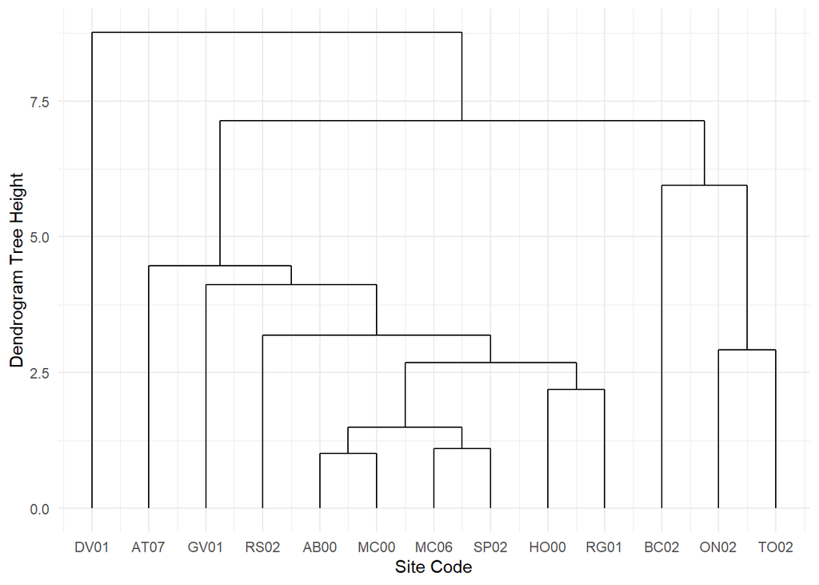

```r
# create distance matrix
sbc_dist = dist(sbc_scale, method = 'euclidean', )

# heirarchical clustering based on complete linkage
sbc_hc_complete = hclust(sbc_dist, method = 'complete')

# plot using base plot
#plot(sbc_hc_complete, cex = 0.6, hang = -1)
ggdendrogram(sbc_hc_complete,
             rotate = FALSE, labels = TRUE, leaf_labels = TRUE, fill = "blue") +
  theme_minimal() +
  labs(x = "Site Code",  y= "Dendrogram Tree Height")
```

Figure 1: A dendrogram of Santa Barbara Coastal LTER sites based on all observed chemical and solid quantities.

## Summary

The heirarchical clustering dendrogram leads to two clear groupings of either 3 or 4 clusters. In both groupings, cluster 1 contains only site DVO1 (Devereaux Creek), and cluster 2 contains sites AT07, GV01, RS02, AB00, MC00, MC06, SP02, H00, and RG01 (see source metadata for site code definitions). One grouping then only has a third cluster, conaining BC02, ON02, and TO02, and the fourth splits BC02 into it’s own cluster. The devereux site having it’s own cluster is likely in part due to it’s dramatically increased NH4 concentraions, greater than 3x more than the next site.

## Data Citation

Santa Barbara Coastal LTER and J. Melack. 2019. SBC LTER: Land: Stream chemistry in the Santa Barbara Coastal drainage area, ongoing since 2000 ver 16. Environmental Data Initiative. https://doi.org/10.6073/pasta/67a558a24ceed9a0a5bf5e46ab841174.